# Prediction with Machine Learning

Vinod M

Monday, May 18, 2015

### Executive Summary

This study analyses data generated by sensors attached to a human body while performing a universal bicep curl both correctly and incorrectly and trains an algorithm to differentiate between them. It then uses the algorithm to predict the outcome(labelled “classe”) in the dataset. The data for this study comes from another original study ,details here : http://groupware.les.inf.puc-rio.br/har.

### Exploratory Analysis

When we open the dataset in R we notice that a lot of columns have missing data except when the new_window parameter is set to “yes”. Going through the original study document the researches have performed aggregates of raw data at specific intervals and these are not relevant to this study and hence those rows are excluded. WE then split the data into training and test sets.

```r
suppressWarnings(library(caret));
suppressWarnings(library(randomForest))
x <- read.csv("c:/RLearning/pml-training.csv",stringsAsFactors =FALSE)
x1 <- subset(x,new_window=="no")
intrain <- createDataPartition(x1$classe,p=.7,list=F)
trainx <- x1[intrain,]
testx <- x1[-intrain,]
```

Plotting some predictors show strong correlation among certain predictors. In the analysis below we will drop one of the strongly correlated columns.

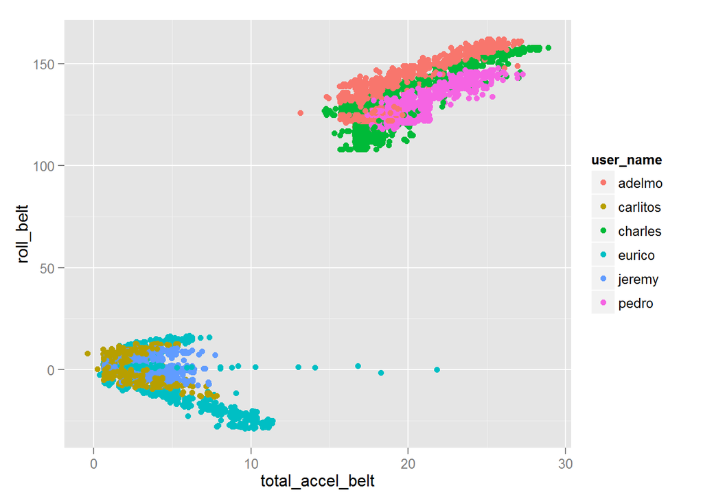

```r
par(mfrow=c(1,2))
qplot(total_accel_belt,roll_belt,data=x1,color=user_name,geom=c("jitter"))
```

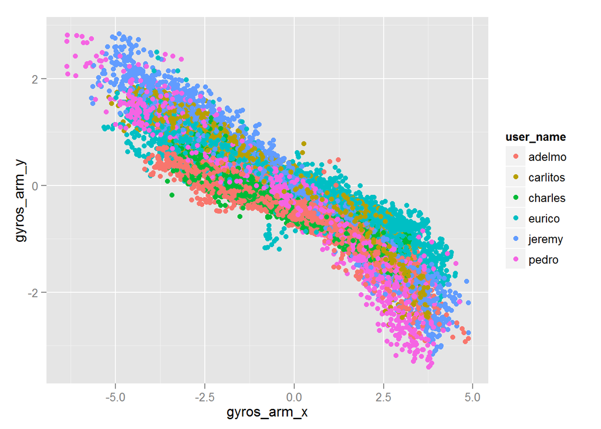

```r
qplot(gyros_arm_x,gyros_arm_y,data=x1,color=user_name,geom=c("jitter"))
```

Next we drop the irrelevant columns (the first 7 colums). We also leave the classe for now and only extract the predictors

```r
cols = colnames(x)[8:159]

x2 <- trainx[,cols]
```

We check which columns have no data (zero or NA)

```r
x2 <- apply(x2,2,as.numeric)
x2 <- data.frame(x2,stringsAsFactors =FALSE)
#find which columns have NA or zero values get these column names
sm <- apply(x2,2,sum,na.rm=TRUE)
```

We drop these columns as they do not contribute to the end result

```r
x3 <- x2[,-which(sm ==0)]
```

We try to determine what set of predictors uniquely effect the outcome and this we obtain by doing a correlation among all predictors and determine which are highly correlated

```r
#function that calculates most highly correlated columns in order

correlationofpredictors <- function(inputdataframe,maxnum)
{
    # find the correlations
    cormatrix <- cor(inputdataframe)
    # set the correlations on the diagonal or lower triangle to zero,
    # so they will not be reported as the highest ones:
    diag(cormatrix) <- 0
    cormatrix[lower.tri(cormatrix)] <- 0
    # flatten the matrix into a dataframe for easy sorting
    fm <- as.data.frame(as.table(cormatrix))
    # assign human-friendly names
    names(fm) <- c("First.Variable", "Second.Variable","Correlation")
    # sort and print the top n correlations
    head(fm[order(abs(fm$Correlation),decreasing=T),],n=maxnum)
}

#find the top 25 highly
corr <- correlationofpredictors(x3,25)
#get the ones that correlate > 0.9 absoulte value
corvals <- corr[abs(corr$Correlation) > .9,]

print(corvals)
```

```
##        First.Variable  Second.Variable Correlation
## 469         roll_belt     accel_belt_z  -0.9920708
## 1695 gyros_dumbbell_x gyros_dumbbell_z  -0.9853473
## 157         roll_belt total_accel_belt   0.9812423
## 472  total_accel_belt     accel_belt_z  -0.9750714
## 366        pitch_belt     accel_belt_x  -0.9651742
## 2373 gyros_dumbbell_z  gyros_forearm_z   0.9536194
## 2371 gyros_dumbbell_x  gyros_forearm_z  -0.9403076
## 477      accel_belt_y     accel_belt_z  -0.9327339
## 420  total_accel_belt     accel_belt_y   0.9282080
## 417         roll_belt     accel_belt_y   0.9239254
## 954       gyros_arm_x      gyros_arm_y  -0.9182075
```

We drop one set of highly correlated columns and append the “classe” outcome for the subsequent training exercise.

```r
cls <- as.character(unique(corvals$First.Variable))
ins <- 0
#remove those columns from data
for(i in 1:length(cls)){ins[i] <- which(colnames(x3)==cls[i])}
x34 <- subset(x3,select = -ins)


classe <- trainx[,"classe"]

x4 <- cbind(x34,classe)
```

### Training and Prediction

We use the random forest algorithm to train the data. Cross Validation is performed using k=6 folds.

```r
tr <- trainControl(method = "cv", number = 6)
zz <- train(x4$classe ~ ., method = "rf", trControl = tr,
    x4)
print(zz)
```

```
## Random Forest
##
## 13453 samples
##    45 predictor
##     5 classes: 'A', 'B', 'C', 'D', 'E'
##
## No pre-processing
## Resampling: Cross-Validated (6 fold)
##
## Summary of sample sizes: 11212, 11209, 11210, 11211, 11212, 11211, ...
##
## Resampling results across tuning parameters:
##
##   mtry  Accuracy   Kappa      Accuracy SD  Kappa SD
##    2    0.9888501  0.9858921  0.002053875  0.002599042
##   23    0.9892966  0.9864568  0.001539854  0.001949173
##   45    0.9840931  0.9798716  0.005074373  0.006421635
##
## Accuracy was used to select the optimal model using  the largest value.
## The final value used for the model was mtry = 23.
```

The insample error rate is at the matching mtry = (1-.99)x100 = 1%.

We use the trained model to predict on the test data :

```r
zz1 <- predict(zz,newdata=testx)
errorrate <- 100 - sum(zz1 == testx$classe)*100/nrow(testx)
```

The out-ofsample error rate is 0.225577 %

Finally we apply this model to the test data set https://d396qusza40orc.cloudfront.net/predmachlearn/pml-testing.csv

```r
test <-  read.csv("c:/RLearning/pml-testing.csv",stringsAsFactors =FALSE)
zz2 <- predict(zz,newdata=test)
print(zz2)
```

```
##  [1] B A B A A E D B A A B C B A E E A B B B
## Levels: A B C D E
```

Comparing to the actual test results shows this 100% accurate